# Contraceptive Use and Access in Ethiopia

Helen Mered Habte

2025-06-30

# Introduction

Family planning plays a critical role in improving maternal and child health, empowering women, and supporting economic development. In Ethiopia, the promotion of contraceptive use has been a major component of national health policy over the past two decades. Despite improvements in awareness and access, challenges remain in equitable access and consistent uptake of modern contraceptive methods across regions and socio-demographic groups.

This report analyzes data from the Ethiopia Demographic and Health Survey (DHS) 2011 to examine patterns of contraceptive use among women of reproductive age (15-49). The goal is to better understand how usage varies by education level, wealth status, place of residence, and age group. By identifying trends and disparities, this analysis aims to inform future strategies for more inclusive family planning programs.

# Objectives

- To assess women’s knowledge and use of family planning methods in Ethiopia
- To explore how family planning use and access vary by education, age, wealth, and place of residence

# Methods of contraceptive use

The overall distribution of contraceptive method use among Ethiopian women aged 15–49, based on the 2011 DHS data, shows that 76.2% of women reported not using any contraceptive method. Among those who did, modern methods were the most commonly used (23.2%), followed by traditional methods (0.6%) and a negligible share using folkloric methods (0.0%).These results highlight a significant unmet need for contraception, as the vast majority of women remain outside the formal family planning system. Despite the presence of modern methods, overall uptake remains low relative to the target population.

| Contraceptive Method | Total | Percentage |
| --- | --- | --- |
| no method | 6768 | 76.2 |
| folkloric method | 1 | 0.0 |
| traditional method | 55 | 0.6 |
| modern method | 2061 | 23.2 |

# Contraceptive Use by Socio-Demographic Factors

## Education

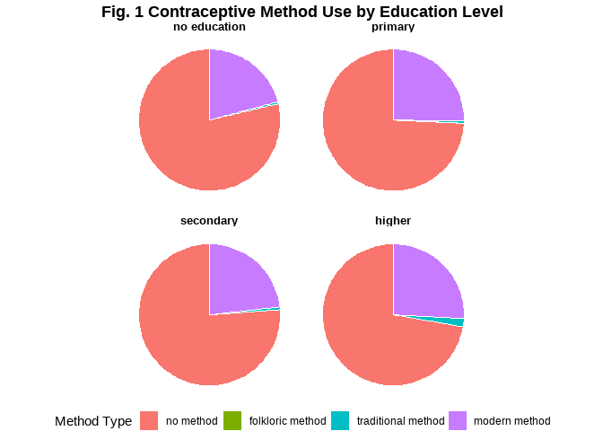

## Age Group

Contraceptive use is highest among women aged 25–34, aligning with peak reproductive years. The youngest (15–19) and oldest (45–49) groups show the highest rates of non-use, suggesting a combination of lower demand and limited service access or autonomy. The low uptake in younger women may also reflect cultural or societal barriers around youth contraceptive access.

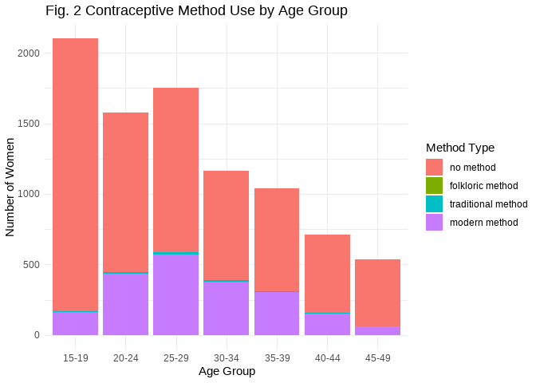